# quizz_1_intro_pandas

#### 1. To load the dataset shown in the image below, which command is appropriate? The dataset is named `spending.csv` and is located in the current directory. Additionally, the column order in `spending.csv` matches the order presented in the image.

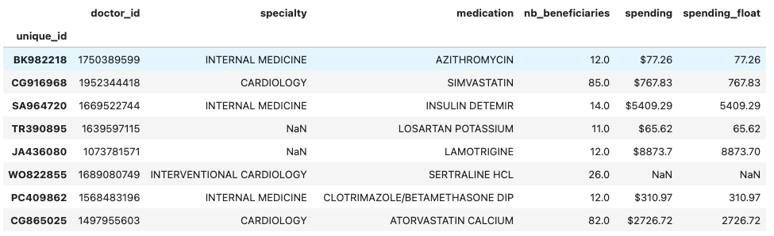

```
1- pd.read_csv("spending.csv", index_col="unique_id")
2- pd.read_csv("spending.csv", columns="unique_id")
3- pd.read_csv("spending.csv")
4- pd.read_csv("spending.csv", ncols=3, usecols=["unique_id", "specialty"])
```

[output not shown]

#### 3. Assuming the data was saved to spending_df, which of the following solutions is a valid way select rows 0, 3, 7 and 21 from the dataframe above?

```
1- spending_df[[0, 3, 7, 21]]
2- spending_df[[0, 3, 7, 21],:]
3- spending_df.iloc[[0, 3, 7, 21]]
4- spending_df.iloc[0, 3, 7, 21]
```

#### 4. Which method can be used to count the number of missing values (NaN) in each column as shown below?

```
doctor_id           0
specialty           6
medication          1
nb_beneficiaries    4
spending            4
spending_float      4
dtype: int64
```

```
1- spending_df.isna()
2- spending_df.isna().sum(axis=0)
3- spending_df.isna().sum(axis=1)
3- spending_df.isna().shape
```

#### 5. Assuming 'spending_df' is a DataFrame with columns including 'specialty' and 'spending', and 'nb_beneficiaries', the following code snippet is intended to normalize the 'spending' by 'nb_beneficiaries' (i.e., calculate 'spending' / 'nb_beneficiaries') specifically for entries where the 'specialty' is "INTERNAL MEDICINE". Given that 'spending_df' has a shape of (54, 6) and there are 13 entries with the specialty "INTERNAL MEDICINE" what does the following snippet return?

```
type(spending_df["spending_float"][internal_med_filter] / spending_df["nb_beneficiaries"])
```

```
1- Error!
2- Series with a dimension of (54, 6)
3- Series with a dimension of (13, )
4- Series with a dimension of (1, 6)
```

#### 6. Which of the following code snippets can be used to **filter out** instances where `specialty` is "INTERNAL MEDICINE" and `nb_beneficiaries` is greater than or equal to 12?

```
1- spending_df[not (spending_df["specialty"] == "INTERNAL MEDICINE") and  (spending_df["nb_beneficiaries"] >= 12)]
1- spending_df[(spending_df["specialty"] == "INTERNAL MEDICINE") and  (spending_df["nb_beneficiaries"] >= 12)]
3- spending_df[~((spending_df["specialty"] == "INTERNAL MEDICINE") &  (spending_df["nb_beneficiaries"] >= 12))]
4- spending_df[(spending_df["specialty"] != "INTERNAL MEDICINE") &  (spending_df["nb_beneficiaries"] >= 12)]
```

#### 7. Which of the following snippets returns the number of rows where `nb_beneficiaries` is greater than 100?

```
1- (spending_df['nb_beneficiaries'] > 100).sum()
2- spending_df['nb_beneficiaries'] > 100
3- spending_df[(spending_df['nb_beneficiaries'] > 100)].shape[0]
4- (spending_df['nb_beneficiaries'] > 100).shape[0]
```

#### 8. Consider the the two following DataFrames:

```
first_df  = pd.DataFrame({"A": [1, 2, 3, 4, 5]})
second_df =  pd.DataFrame({"A": [1, 2, 3, 4, 5]}, index= [f"row_{i}" for i in range(5)])
```

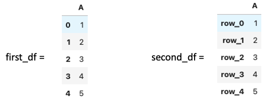

What does the following snippet return?

```
first_df["A"] + second_df["A"]).shape
```

```
1- (10,)
2- (5,)
3- (5,2)
4- Error
```